# Análise sobre avaliações de séries de TV pelo IMDb

#### Importando os dados

O primeiro passo desta análise é importar os dados a serem utilizados e filtrar as séries de interesse.

```r
episodes = read_csv(here("data/series_from_imdb.csv"),
                    progress = FALSE,
                    col_types = cols(.default = col_double(),
                                     series_name = col_character(),
                                     episode = col_character(),
                                     url = col_character(),
                                     season = col_character()))
```

## Apresentando uma visão geral das variáveis que são usadas na análise

**Número de votos por episódio**

```r
summary(episodes$user_votes)
```

```
    Min.  1st Qu.   Median     Mean  3rd Qu.     Max.
     5.0     76.0    211.0    617.6    636.0 138353.0
```

Um resumo sobre o número de votos por episódio está descrito acima: Com valor mínimo igual a 5 votos, valor máximo igual a 138.3533 e mediana igual a 211 (significando que 50% do número de votos está abaixo de 211 e 50% está acima desse valor). Acredito que esses dados estão relativamente dispersos, uma vez que 75% deles estão abaixo ou igual a 636 e o restante provavelmente está bastante disperso e/ou possui outliers com valores bastante elevados.

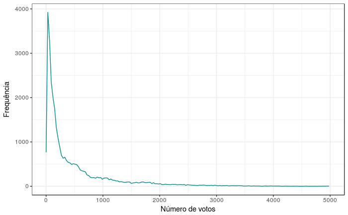

```r
episodes %>% ggplot(aes(user_votes)) +
  geom_freqpoly(binwidth = 30, color = 'darkcyan') + xlim(0, 5000) + labs(x = 'Número de votos', y = 'Frequência')
```

Percebemos que o número de votos está distribuído em sua maioria entre 5 (menor número) a 2000, com maior concentração entre 5 e aproximadamente 250 votos, indicando que os dados se concentram mais nesse intervalo.

**Avaliações dos episódios**

```r
summary(episodes$user_rating)
```

```
   Min. 1st Qu.  Median    Mean 3rd Qu.    Max.
  3.000   7.600   8.000   7.933   8.400   9.900
```

Os dados de avaliação dos episódios estão distribuídos da seguinte forma: valor mínimo igual a 3, valor máximo igual a 9.9 e mediana igual a 8. Observaremos a seguir a distribuição dessa variável:

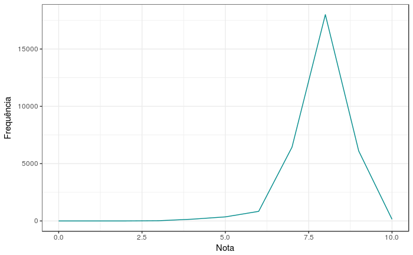

```r
episodes %>% ggplot(aes(user_rating)) +
  geom_freqpoly(binwidth = 1, color = 'darkcyan') + xlim(0, 10) + labs(x = 'Nota', y = 'Frequência')
```

Pelo gráfico, observamos que a maior parte dos votos está entre 7.5 e aproximadamente 8.7. Acredito que não muita dispersão nos dados.

## Perguntas

### Os episódios que recebem mais votação são episódios mais amados ou mais odiados?

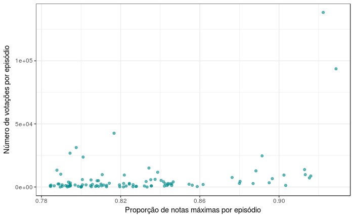

```r
top_100_votes = episodes %>% arrange(-user_votes) %>% top_n(100)
top_100_votes %>%
  ggplot(aes(x = r10, y = user_votes)) +
  geom_point(alpha = 0.6, color = 'darkcyan') +
  labs(x = 'Proporção de notas máximas por episódio', y = 'Número de votações por episódio')
```

O gráfico acima ilustra a relação entre o número de votações dos 100 episódios mais bem votados e a proporção de usuários que deram nota máxima. Olhando para o gráfico, percebe-se que não há uma relação muito relevante entre o número de votos e a proporção de nota máxima, pois tirando os pontos extremos, a distribuição da proporção em relação ao número de votos encontra-se quase constante, independendo do número de votos.

Outra forma de visualizar se há relação ou não é calcular o coeficiente de correlação entre essas duas variáveis. Com coeficiente de correlação próximo a 0.39, assume-se que há correlação fraca entre o número de votos e a proporção de episódios mais amados.

```r
cor(top_100_votes$user_votes, top_100_votes$r10)
```

```
[1] 0.3869726
```

A seguir, fazemos o mesmo para a proporção de notas mais baixas a fim de saber se os episódios mais votados são mais odiados.

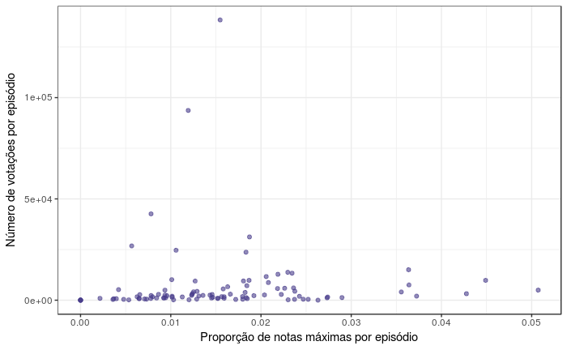

```r
top_100_votes %>%
  ggplot(aes(x = r1, y = user_votes)) +
  geom_point(alpha = 0.6, color = 'darkslateblue') +
  labs(x = 'Proporção de notas máximas por episódio', y = 'Número de votações por episódio')
```

Observando o gráfico acima, nota-se que os episódios mais votados se concentram onde há menor proporção de notas com valor mínimo. Isto significa que normalmente os episódios mais votados são menos odiados.

Abaixo tem-se calculado o coeficiente de correlação entre o número de votos e a proporção de notas mínimas por episódio. Com valor igual a aproximadamente 0.03 assume-se que há uma correlação bem fraca, indicando que a proporção de votos com nota mínima é fracamente proporcional ao número de votos.

```r
cor(top_100_votes$user_votes, top_100_votes$r1)
```

```
[1] 0.03006509
```

Um questionamento que esta reposta pode levar é **se o número de votação por episódio (a popularidade) está associado à longevidade das séries**.

### O número de votação por episódio (a popularidade) está associado à longevidade das séries?

Para responder à esta pergunta, considerei como séries longas as séries que possuem mais de 100 episódios em seu total.

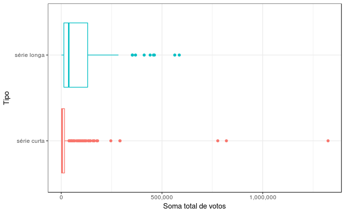

```r
series_longas_votos = episodes %>% group_by (series_name) %>%
    summarise(cont_total = n(), soma_votos = sum(user_votes)) %>%
    mutate(tipo_serie = case_when(cont_total >= 100 ~ 'série longa',
                                  cont_total < 100 ~ 'série curta'))
series_longas_votos %>%
    ggplot(aes(x = tipo_serie, y = soma_votos, color = tipo_serie)) +
    geom_boxplot() + coord_flip() +
    theme(legend.position = 'None') +
    labs (x = 'Tipo', y = 'Soma total de votos') + scale_y_continuous(labels = scales::comma)
```

Os boxplots acima indicam que as três séries com maior número total de votos são curtas, ou seja, possuem menos de 100 episódios (a nível de curiosidade, veremos quais são a seguir). Percebemos também que, em geral, as séries que recebem mais votos são sim as mais longas.

As séries curtas mais populares são:

```r
series_longas_votos %>% arrange(-soma_votos) %>% head(3)
```

| series_name | cont_total | soma_votos | tipo_serie |
| --- | --- | --- | --- |
| Game of Thrones | 60 | 1324411 | série curta |
| The Walking Dead | 99 | 819872 | série curta |
| Breaking Bad | 62 | 776976 | série curta |

Nessa tabela fica clara a popoularidade de Game of Thrones, conquistando mais de 1 milhão e 300 mil votos ao todo com 60 episódios. The Walking Dead está quase classificada como série longa, pois possui 99 episódios, e ocupa o segundo lugar com mais de 800 mil votos. Em terceiro está Breaking Bad, com 776 mil votos e 62 episódios.

### Qual o gênero de série mais bem avaliado?

Precisamos criar essa variável nos dados. Como são muitas séries, optou-se por escolher as 10 séries mais bem avaliadas e adicionar o gênero somente a elas.

```
Ignoring unknown parameters: binwidth, bins, pad
```

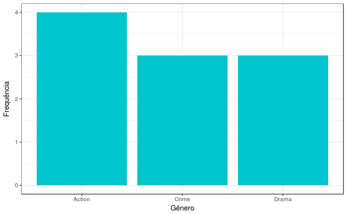

```r
top_10_series %>% ggplot(aes(x = gender)) +
    geom_histogram(stat = 'count', fill = 'turquoise3') +
    labs(x = 'Gênero', y = 'Frequência')
```

Não se tem uma diferença grande entre os gêneros mais bem votados, seguida de Crime e Drama. Acredito que normalmente os três gêneros andam juntos em muitas das séries selecionadas para responder a esta pergunta.

Outra coisa que se pode investigar é quais são os gêneros das séries com nota menor do IMDb, e será respondido a seguir.

```
Ignoring unknown parameters: binwidth, bins, pad
```

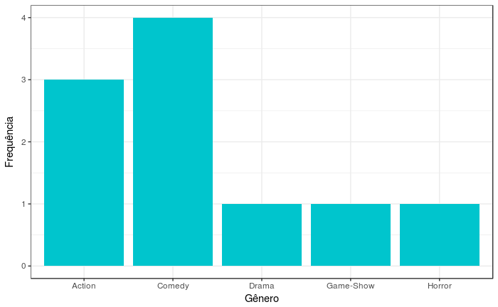

```r
top_minus_10_series = episodes %>% group_by(series_name) %>% summarise(mean_rating = mean(user_rating)) %>% arrange(mean_rating) %>% head(10)
# Adicionando coluna gender com o gênero predominante da série
top_minus_10_series$gender = c("Game-Show", "Action", "Action", "Comedy", "Drama", "Comedy", "Comedy", "Comedy", "Action", "Horror")
top_minus_10_series %>% ggplot(aes(x = gender)) +
    geom_histogram(stat = 'count', fill = 'turquoise3') +
    labs(x = 'Gênero', y = 'Frequência')
```

O gênero das séries com notas mais baixas é Comédia, seguido de Ação, Drama, Game-Show e Horror. Achei interessante o gênero Ação estar tanto nas séries mais bem avaliadas quanto nas que possuem nota mais baixas, o que pode significar que o gênero não tem muita relação com o sucesso e a popularidade da série.